# Introduction to R, part B

cs4821-s17

IntroA | IntroB | IntroC | IntroD

## Working with Data

R has provided a number of built-in data sets. A list of data sets available can be viewed with:

```r
data()
```

## First Installation of Library

Let’s explore using R with the *mpg* data set available in the *ggplot2* library. If you have not yet installed this library on your computer/account then you will get the following error: `Error: there is no package called 'ggplot2'`

The first installation is down with the following command:

```r
install.packages('ggplot2')
```

Once a package has been installed, then when you desire to use its functions, the library only needs to be loaded.

```r
library(ggplot2)
data(mpg)
```

## Data Set Functions

Information about the data set may be viewed via in the Files/Plot/Packages/Help Panel of RStudio

```r
help(mpg)
```

A basic summary of the variables can be assessed by

```r
summary(mpg)
```

```
##  manufacturer          model               displ            year
##  Length:234         Length:234         Min.   :1.600   Min.   :1999
##  Class :character   Class :character   1st Qu.:2.400   1st Qu.:1999
##  Mode  :character   Mode  :character   Median :3.300   Median :2004
##                                        Mean   :3.472   Mean   :2004
##                                        3rd Qu.:4.600   3rd Qu.:2008
##                                        Max.   :7.000   Max.   :2008
##       cyl           trans               drv                 cty
##  Min.   :4.000   Length:234         Length:234         Min.   : 9.00
##  1st Qu.:4.000   Class :character   Class :character   1st Qu.:14.00
##  Median :6.000   Mode  :character   Mode  :character   Median :17.00
##  Mean   :5.889                                         Mean   :16.86
##  3rd Qu.:8.000                                         3rd Qu.:19.00
##  Max.   :8.000                                         Max.   :35.00
##       hwy             fl               class
##  Min.   :12.00   Length:234         Length:234
##  1st Qu.:18.00   Class :character   Class :character
##  Median :24.00   Mode  :character   Mode  :character
##  Mean   :23.44
##  3rd Qu.:27.00
##  Max.   :44.00
```

An alternative view of the data can be found by

```r
str(mpg)
```

```
## Classes 'tbl_df', 'tbl' and 'data.frame':    234 obs. of  11 variables:
##  $ manufacturer: chr  "audi" "audi" "audi" "audi" ...
##  $ model       : chr  "a4" "a4" "a4" "a4" ...
##  $ displ       : num  1.8 1.8 2 2 2.8 2.8 3.1 1.8 1.8 2 ...
##  $ year        : int  1999 1999 2008 2008 1999 1999 2008 1999 1999 2008 ...
##  $ cyl         : int  4 4 4 4 6 6 6 4 4 4 ...
##  $ trans       : chr  "auto(l5)" "manual(m5)" "manual(m6)" "auto(av)" ...
##  $ drv         : chr  "f" "f" "f" "f" ...
##  $ cty         : int  18 21 20 21 16 18 18 18 16 20 ...
##  $ hwy         : int  29 29 31 30 26 26 27 26 25 28 ...
##  $ fl          : chr  "p" "p" "p" "p" ...
##  $ class       : chr  "compact" "compact" "compact" "compact" ...
```

The dimensions of the data (rows, columns) can be found by

```r
dim(mpg)
```

```
## [1] 234  11
```

To look at the raw data, the top of the data matrix can be peeked at with

```r
head(mpg)
```

```
## # A tibble: 6 × 11
##   manufacturer model displ  year   cyl      trans   drv   cty   hwy    fl
##          <chr> <chr> <dbl> <int> <int>      <chr> <chr> <int> <int> <chr>
## 1         audi    a4   1.8  1999     4   auto(l5)     f    18    29     p
## 2         audi    a4   1.8  1999     4 manual(m5)     f    21    29     p
## 3         audi    a4   2.0  2008     4 manual(m6)     f    20    31     p
## 4         audi    a4   2.0  2008     4   auto(av)     f    21    30     p
## 5         audi    a4   2.8  1999     6   auto(l5)     f    16    26     p
## 6         audi    a4   2.8  1999     6 manual(m5)     f    18    26     p
## # ... with 1 more variables: class <chr>
```

## Indexing (Subscripting)

Any part of the data matrix may be viewed via indexing (also referred to as subscripting)

```r
mpg[100:109,]
```

```
## # A tibble: 10 × 11
##    manufacturer  model displ  year   cyl      trans   drv   cty   hwy
##           <chr>  <chr> <dbl> <int> <int>      <chr> <chr> <int> <int>
## 1         honda  civic   1.6  1999     4 manual(m5)     f    28    33
## 2         honda  civic   1.6  1999     4   auto(l4)     f    24    32
## 3         honda  civic   1.6  1999     4 manual(m5)     f    25    32
## 4         honda  civic   1.6  1999     4 manual(m5)     f    23    29
## 5         honda  civic   1.6  1999     4   auto(l4)     f    24    32
## 6         honda  civic   1.8  2008     4 manual(m5)     f    26    34
## 7         honda  civic   1.8  2008     4   auto(l5)     f    25    36
## 8         honda  civic   1.8  2008     4   auto(l5)     f    24    36
## 9         honda  civic   2.0  2008     4 manual(m6)     f    21    29
## 10      hyundai sonata   2.4  1999     4   auto(l4)     f    18    26
## # ... with 2 more variables: fl <chr>, class <chr>
```

The data columns may be accessed by numeric indexing (the 8th - 11th variables) or by name (‘cty’, ‘hwy’, ‘fl’, ‘class’)

```r
mpg[80:85,8:11]
```

```
## # A tibble: 6 × 4
##     cty   hwy    fl  class
##   <int> <int> <chr>  <chr>
## 1    14    17     r    suv
## 2    13    19     r    suv
## 3    13    19     r    suv
## 4    13    17     r    suv
## 5    14    17     r pickup
## 6    14    17     r pickup
```

```r
mpg[80:85,c("cty", "hwy", "fl", "class")]
```

```
## # A tibble: 6 × 4
##     cty   hwy    fl  class
##   <int> <int> <chr>  <chr>
## 1    14    17     r    suv
## 2    13    19     r    suv
## 3    13    19     r    suv
## 4    13    17     r    suv
## 5    14    17     r pickup
## 6    14    17     r pickup
```

A single data frame may be indexed

```r
mpg$hwy[1:20]
```

```
##  [1] 29 29 31 30 26 26 27 26 25 28 27 25 25 25 25 24 25 23 20 15
```

Data may be accessed by indicated items to exclude

```r
mpg[80:85,-1]
```

```
## # A tibble: 6 × 10
##             model displ  year   cyl      trans   drv   cty   hwy    fl
##             <chr> <dbl> <int> <int>      <chr> <chr> <int> <int> <chr>
## 1    explorer 4wd   4.0  1999     6   auto(l5)     4    14    17     r
## 2    explorer 4wd   4.0  2008     6   auto(l5)     4    13    19     r
## 3    explorer 4wd   4.6  2008     8   auto(l6)     4    13    19     r
## 4    explorer 4wd   5.0  1999     8   auto(l4)     4    13    17     r
## 5 f150 pickup 4wd   4.2  1999     6   auto(l4)     4    14    17     r
## 6 f150 pickup 4wd   4.2  1999     6 manual(m5)     4    14    17     r
## # ... with 1 more variables: class <chr>
```

```r
mpg[80:85,-c(1,2,3,4,5)]
```

```
## # A tibble: 6 × 6
##        trans   drv   cty   hwy    fl  class
##        <chr> <chr> <int> <int> <chr>  <chr>
## 1   auto(l5)     4    14    17     r    suv
## 2   auto(l5)     4    13    19     r    suv
## 3   auto(l6)     4    13    19     r    suv
## 4   auto(l4)     4    13    17     r    suv
## 5   auto(l4)     4    14    17     r pickup
## 6 manual(m5)     4    14    17     r pickup
```

## Basic Plots

Let’s try a little visualization:

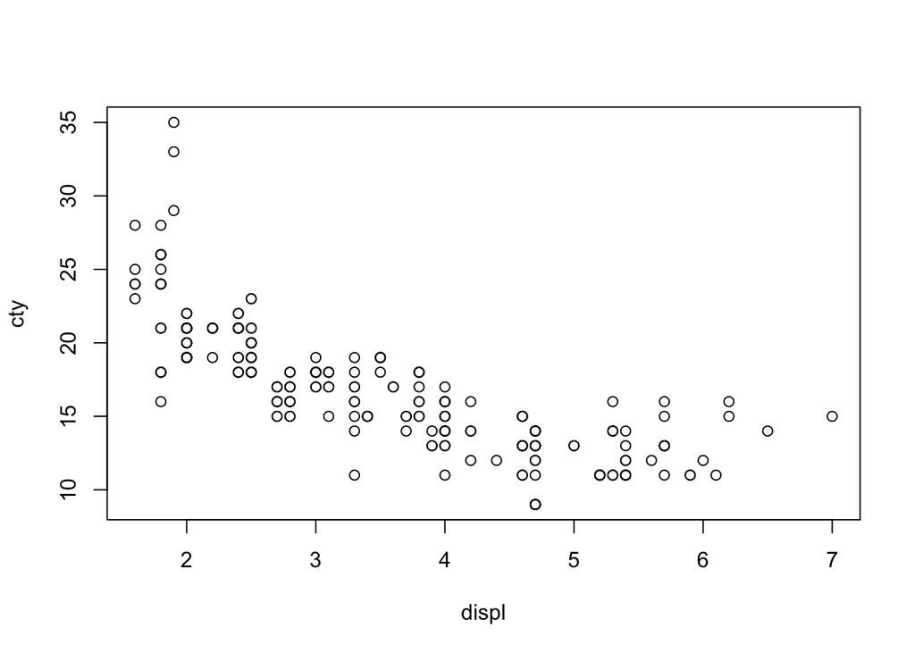

```r
plot(mpg[,c("displ", "cty")])
```

Or a box plot

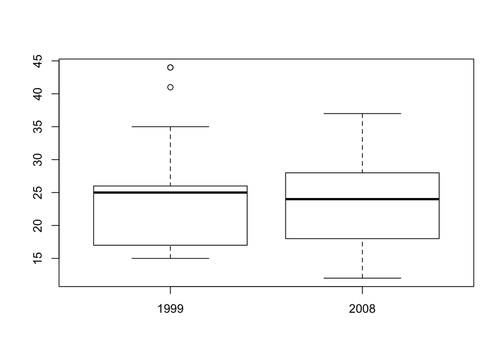

```r
boxplot(mpg$hwy ~ mpg$year)
```

Inspired by and following examples of J. Taylor using Sphinx, R introduction's from D. Cook and L. Turgo, and C. Grandrud's Reproducible Research.

cs4821 - Data Mining - Spring 2017  
updated: January 10, 2017